# Analysis of field and evironmental data- April

####3.1 Is oogonia/receptacle affected by the season?####

```r
lm3.1 <- lm(avg.oog ~ season, data =all)
lm3.1
```

```
##
## Call:
## lm(formula = avg.oog ~ season, data = all)
##
## Coefficients:
##       (Intercept)  seasonspring.2019  seasonsummer.2018  seasonsummer.2019
##            25.753             -1.633             -0.429            -10.591
## seasonwinter.2018
##             7.506
```

```r
summary (lm3.1)
```

```
##
## Call:
## lm(formula = avg.oog ~ season, data = all)
##
## Residuals:
##     Min      1Q  Median      3Q     Max
## -24.120 -11.435  -5.148  11.519  37.454
##
## Coefficients:
##                   Estimate Std. Error t value Pr(>|t|)
## (Intercept)         25.753      5.341   4.822 1.28e-05 ***
## seasonspring.2019   -1.633      7.065  -0.231    0.818
## seasonsummer.2018   -0.429      7.065  -0.061    0.952
## seasonsummer.2019  -10.591      7.065  -1.499    0.140
## seasonwinter.2018    7.506      7.065   1.062    0.293
## ---
## Signif. codes:  0 '***' 0.001 '**' 0.01 '*' 0.05 '.' 0.1 ' ' 1
##
## Residual standard error: 16.02 on 52 degrees of freedom
##   (4 observations deleted due to missingness)
## Multiple R-squared:  0.1297, Adjusted R-squared:  0.06276
## F-statistic: 1.938 on 4 and 52 DF,  p-value: 0.118
```

```r
anova (lm3.1)
```

```
## Analysis of Variance Table
##
## Response: avg.oog
##           Df  Sum Sq Mean Sq F value Pr(>F)
## season     4  1989.4  497.36  1.9375  0.118
## Residuals 52 13348.4  256.70
```

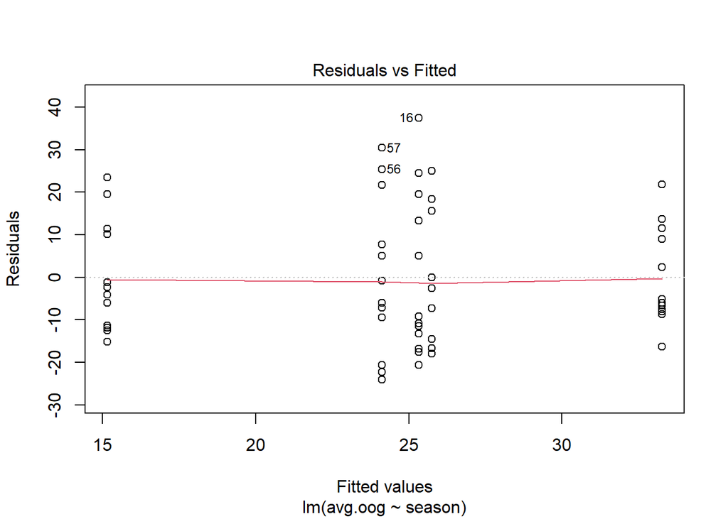

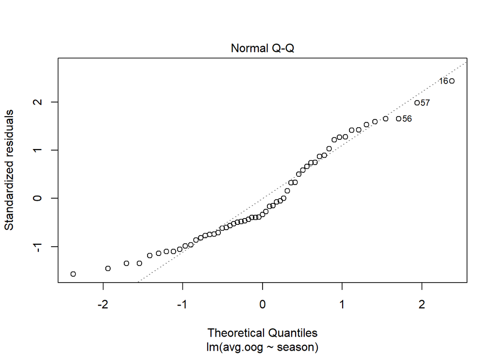

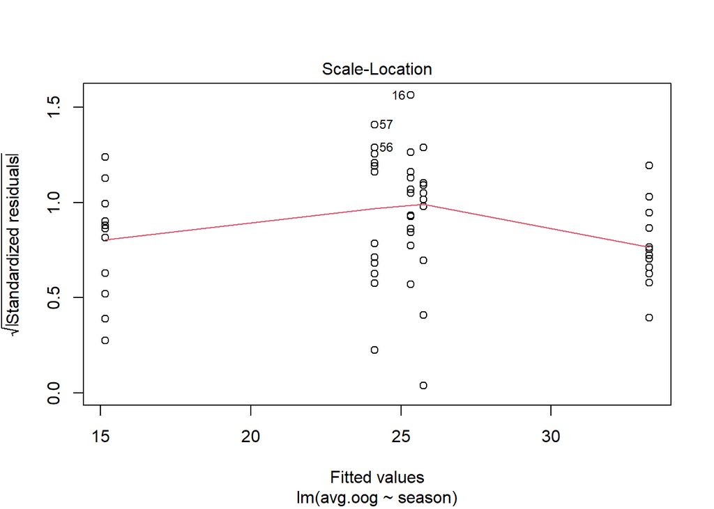

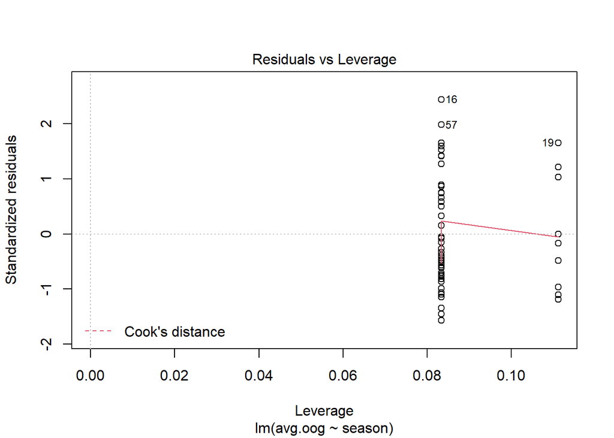

```r
plot (lm3.1)
```

####3.2 Is oogonia/thalli affected by the season?####

```r
lm3.2 <- lm(oog.thalli ~ season, data =all)
lm3.2
```

```
##
## Call:
## lm(formula = oog.thalli ~ season, data = all)
##
## Coefficients:
##       (Intercept)  seasonspring.2019  seasonsummer.2018  seasonsummer.2019
##            397819            -118122            -208708            -252414
## seasonwinter.2018
##           -260220
```

```r
summary (lm3.2)
```

```
##
## Call:
## lm(formula = oog.thalli ~ season, data = all)
##
## Residuals:
##     Min      1Q  Median      3Q     Max
## -386196 -170441  -91554   73943 1757053
##
## Coefficients:
##                   Estimate Std. Error t value Pr(>|t|)
## (Intercept)         397819     115588   3.442  0.00115 **
## seasonspring.2019  -118122     152908  -0.773  0.44331
## seasonsummer.2018  -208708     152908  -1.365  0.17815
## seasonsummer.2019  -252414     152908  -1.651  0.10482
## seasonwinter.2018  -260220     152908  -1.702  0.09476 .
## ---
## Signif. codes:  0 '***' 0.001 '**' 0.01 '*' 0.05 '.' 0.1 ' ' 1
##
## Residual standard error: 346800 on 52 degrees of freedom
##   (4 observations deleted due to missingness)
## Multiple R-squared:  0.07225,    Adjusted R-squared:  0.0008898
## F-statistic: 1.012 on 4 and 52 DF,  p-value: 0.4096
```

```r
anova (lm3.2)
```

```
## Analysis of Variance Table
##
## Response: oog.thalli
##           Df     Sum Sq    Mean Sq F value Pr(>F)
## season     4 4.8698e+11 1.2174e+11  1.0125 0.4096
## Residuals 52 6.2527e+12 1.2024e+11
```

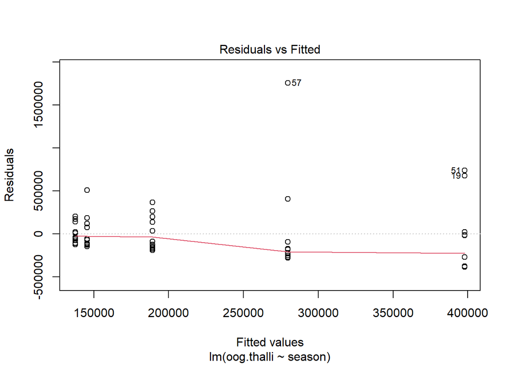

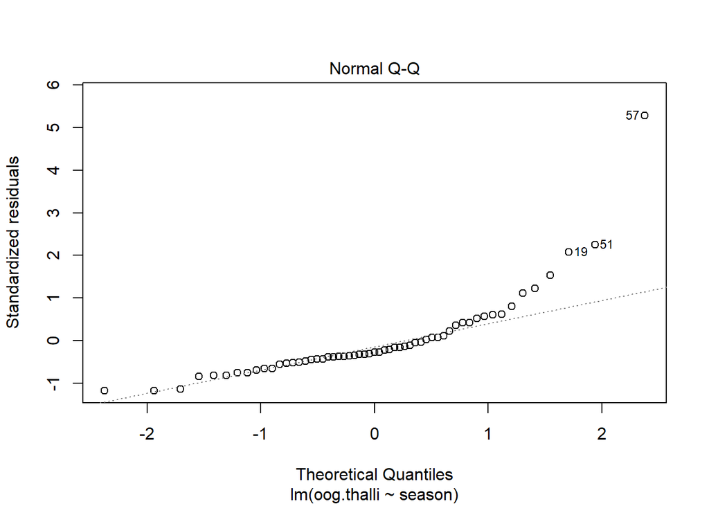

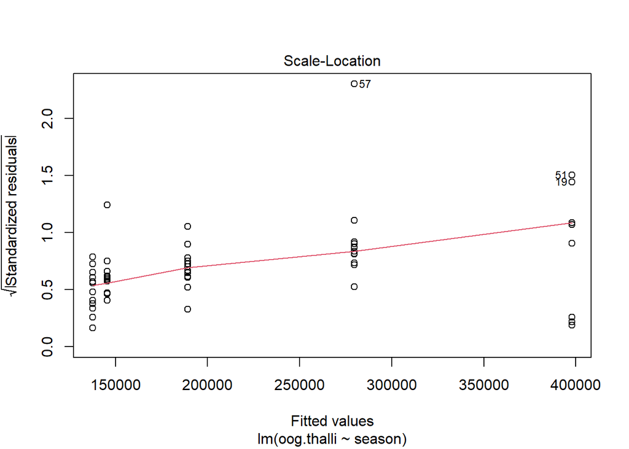

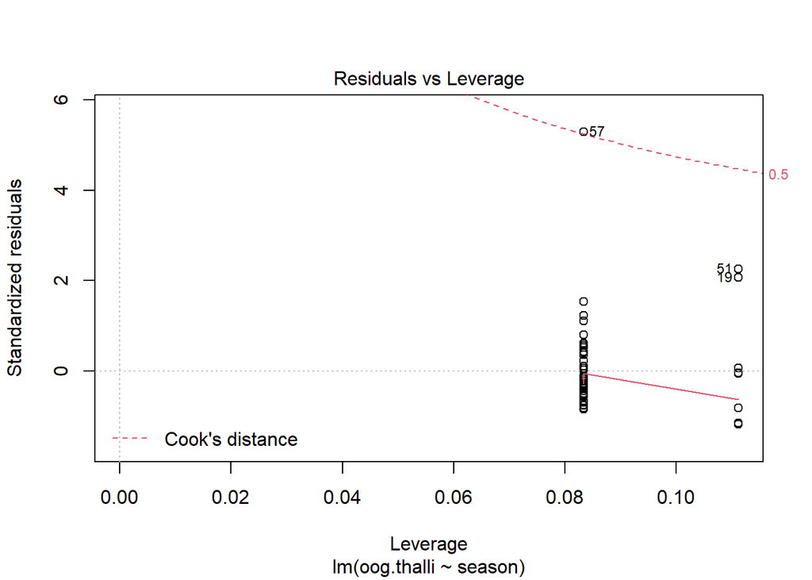

```r
plot (lm3.2)
```

####3.3 Is conceptacle/thalli affected by the season?####

```r
lm3.3 <- lm(con.thalli ~ season, data =all)
lm3.3
```

```
##
## Call:
## lm(formula = con.thalli ~ season, data = all)
##
## Coefficients:
##       (Intercept)  seasonspring.2019  seasonsummer.2018  seasonsummer.2019
##             18468              -3002              -7925              -3119
## seasonwinter.2018
##            -10864
```

```r
summary (lm3.3)
```

```
##
## Call:
## lm(formula = con.thalli ~ season, data = all)
##
## Residuals:
##    Min     1Q Median     3Q    Max
## -16096  -7231  -2131   5639  57509
##
## Coefficients:
##                   Estimate Std. Error t value Pr(>|t|)
## (Intercept)          18468       4245   4.351 6.35e-05 ***
## seasonspring.2019    -3002       5615  -0.535   0.5952
## seasonsummer.2018    -7925       5615  -1.411   0.1641
## seasonsummer.2019    -3119       5615  -0.556   0.5809
## seasonwinter.2018   -10864       5615  -1.935   0.0585 .
## ---
## Signif. codes:  0 '***' 0.001 '**' 0.01 '*' 0.05 '.' 0.1 ' ' 1
##
## Residual standard error: 12730 on 52 degrees of freedom
##   (4 observations deleted due to missingness)
## Multiple R-squared:  0.08934,    Adjusted R-squared:  0.01929
## F-statistic: 1.275 on 4 and 52 DF,  p-value: 0.2916
```

```r
anova (lm3.3)
```

```
## Analysis of Variance Table
##
## Response: con.thalli
##           Df     Sum Sq   Mean Sq F value Pr(>F)
## season     4  827224705 206806176  1.2754 0.2916
## Residuals 52 8431680714 162147706
```

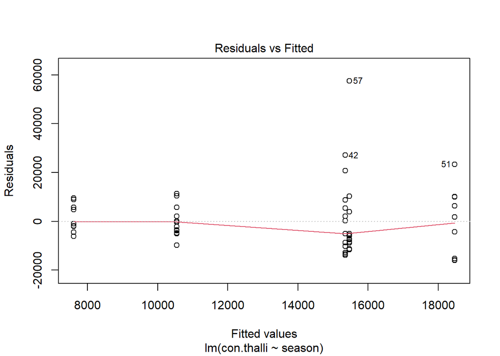

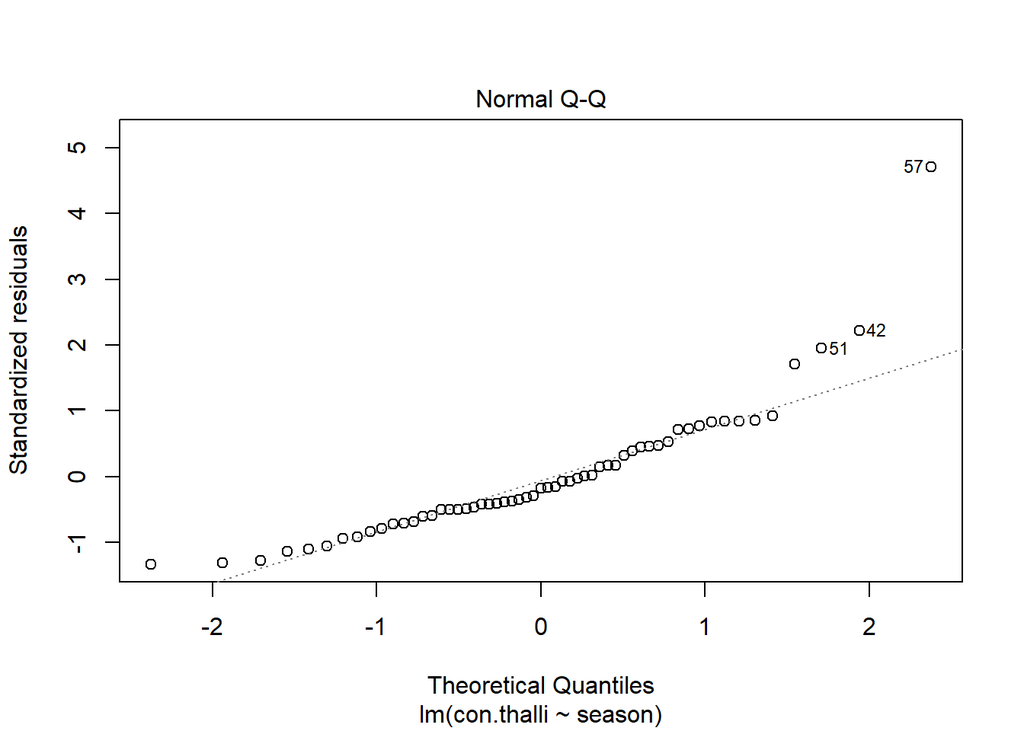

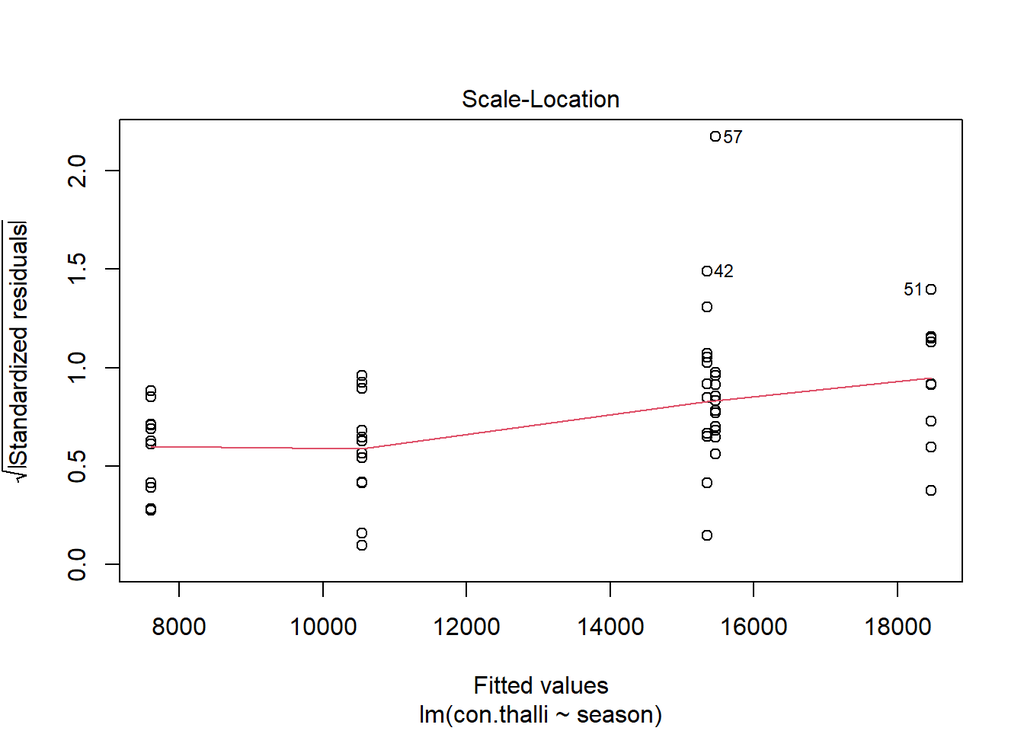

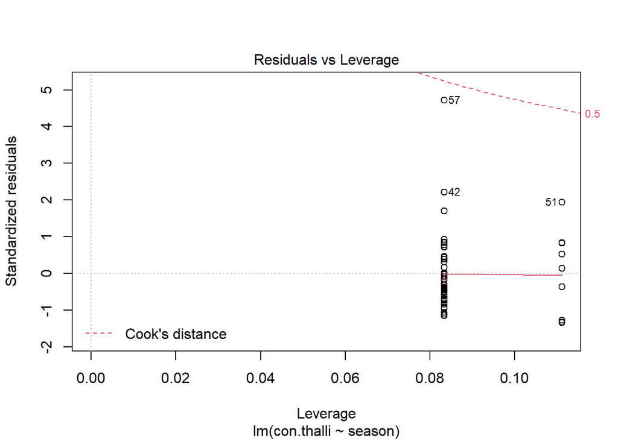

```r
plot (lm3.3)
```

####3.4 Is percent reproductive tissue affected by the season?####

```r
lm3.4 <- lm(perc.rdw ~ season, data =all)
lm3.4
```

```
##
## Call:
## lm(formula = perc.rdw ~ season, data = all)
##
## Coefficients:
##       (Intercept)  seasonspring.2019  seasonsummer.2018  seasonsummer.2019
##            24.367             -8.205             -5.058              1.804
## seasonwinter.2018
##           -11.406
```

```r
summary (lm3.4)
```

```
##
## Call:
## lm(formula = perc.rdw ~ season, data = all)
##
## Residuals:
##     Min      1Q  Median      3Q     Max
## -24.083 -10.392  -1.393   9.394  33.425
##
## Coefficients:
##                   Estimate Std. Error t value Pr(>|t|)
## (Intercept)         24.367      4.575   5.326 2.18e-06 ***
## seasonspring.2019   -8.205      6.052  -1.356   0.1810
## seasonsummer.2018   -5.058      6.052  -0.836   0.4072
## seasonsummer.2019    1.804      6.052   0.298   0.7668
## seasonwinter.2018  -11.406      6.052  -1.885   0.0651 .
## ---
## Signif. codes:  0 '***' 0.001 '**' 0.01 '*' 0.05 '.' 0.1 ' ' 1
##
## Residual standard error: 13.73 on 52 degrees of freedom
##   (4 observations deleted due to missingness)
## Multiple R-squared:  0.1246, Adjusted R-squared:  0.05727
## F-statistic:  1.85 on 4 and 52 DF,  p-value: 0.1332
```

```r
anova (lm3.4)
```

```
## Analysis of Variance Table
##
## Response: perc.rdw
##           Df Sum Sq Mean Sq F value Pr(>F)
## season     4 1394.4  348.59  1.8504 0.1332
## Residuals 52 9796.1  188.39
```

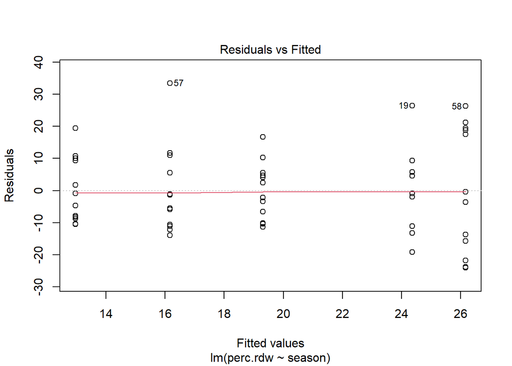

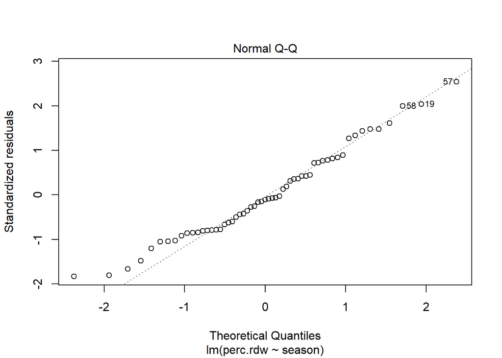

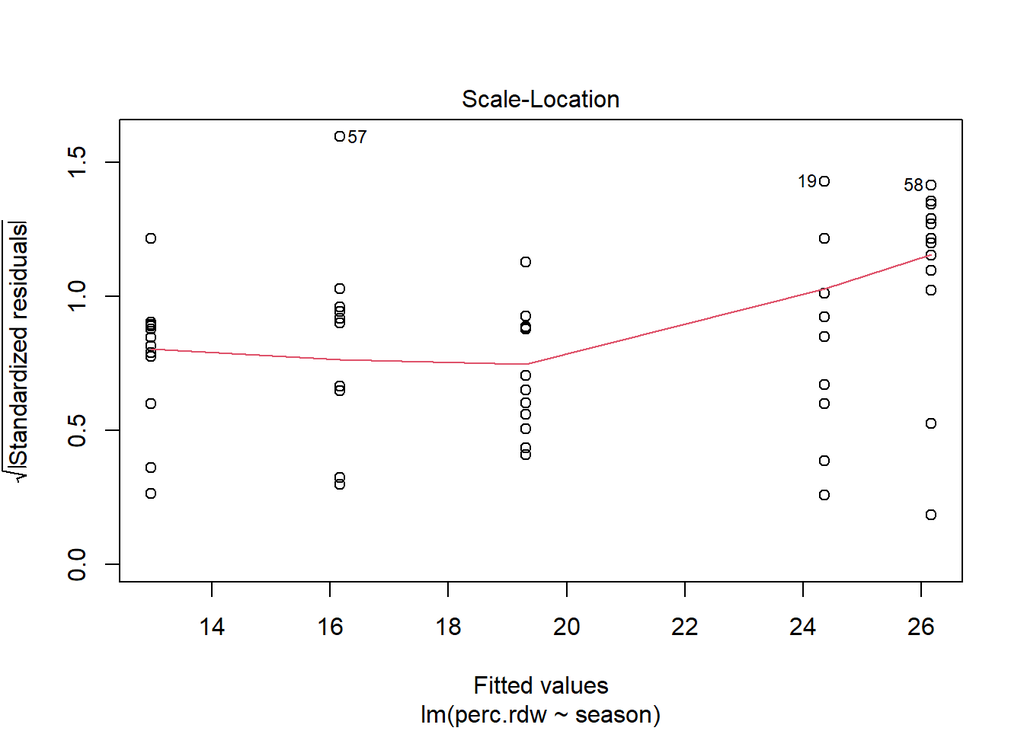

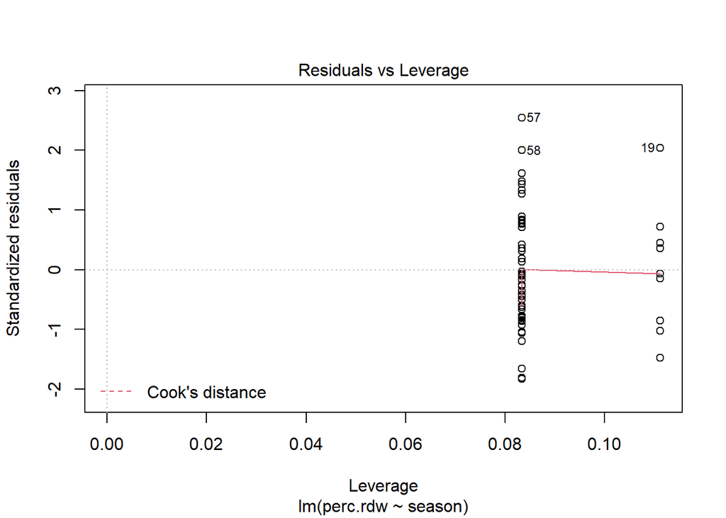

```r
plot (lm3.4)
```

####3.5 Is adult density affected by the season?####

```r
lm3.5 <- lm(no.large.fuc.q ~ season, data =all)
lm3.5
```

```
##
## Call:
## lm(formula = no.large.fuc.q ~ season, data = all)
##
## Coefficients:
##       (Intercept)    seasonfall.2019  seasonspring.2019  seasonsummer.2018
##             5.967             -3.592              3.083              5.646
## seasonsummer.2019  seasonwinter.2018
##            -2.450              1.875
```

```r
summary (lm3.5)
```

```
##
## Call:
## lm(formula = no.large.fuc.q ~ season, data = all)
##
## Residuals:
##     Min      1Q  Median      3Q     Max
## -8.4125 -1.1750 -0.4125  1.2875 11.2875
##
## Coefficients:
##                   Estimate Std. Error t value Pr(>|t|)
## (Intercept)          5.967      1.173   5.085 5.32e-06 ***
## seasonfall.2019     -3.592      2.115  -1.698  0.09564 .
## seasonspring.2019    3.083      1.552   1.986  0.05239 .
## seasonsummer.2018    5.646      1.711   3.300  0.00177 **
## seasonsummer.2019   -2.450      1.552  -1.578  0.12069
## seasonwinter.2018    1.875      1.552   1.208  0.23268
## ---
## Signif. codes:  0 '***' 0.001 '**' 0.01 '*' 0.05 '.' 0.1 ' ' 1
##
## Residual standard error: 3.52 on 51 degrees of freedom
##   (4 observations deleted due to missingness)
## Multiple R-squared:  0.4264, Adjusted R-squared:  0.3702
## F-statistic: 7.582 on 5 and 51 DF,  p-value: 2.184e-05
```

```r
anova (lm3.5)
```

```
## Analysis of Variance Table
##
## Response: no.large.fuc.q
##           Df Sum Sq Mean Sq F value    Pr(>F)
## season     5 469.84  93.968  7.5822 2.184e-05 ***
## Residuals 51 632.05  12.393
## ---
## Signif. codes:  0 '***' 0.001 '**' 0.01 '*' 0.05 '.' 0.1 ' ' 1
```

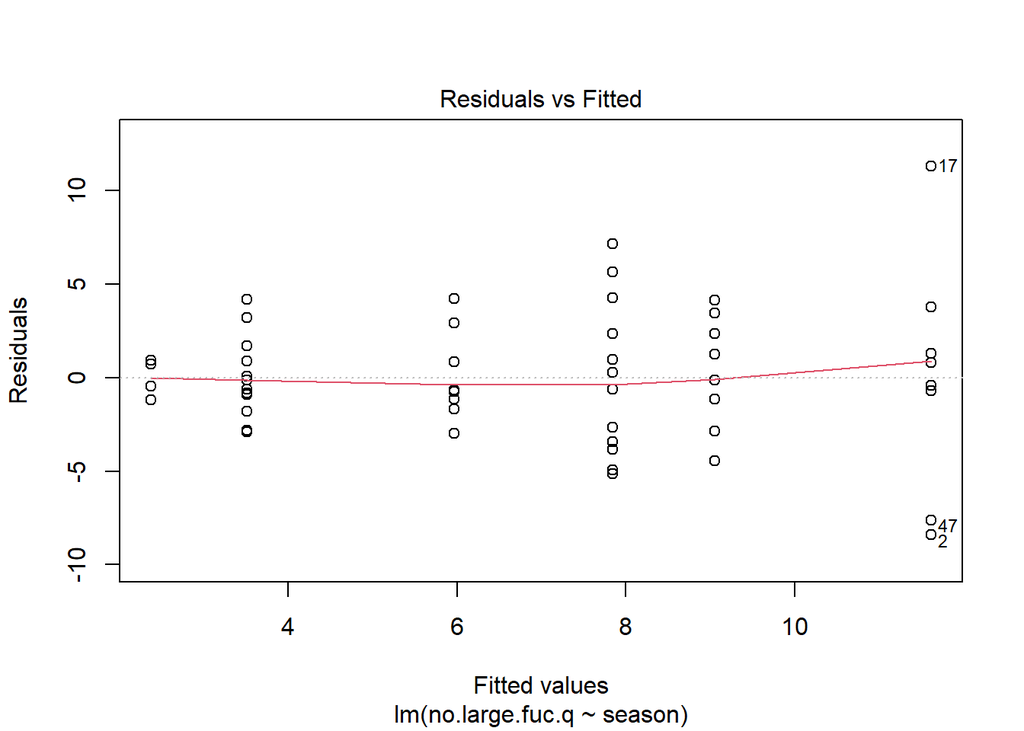

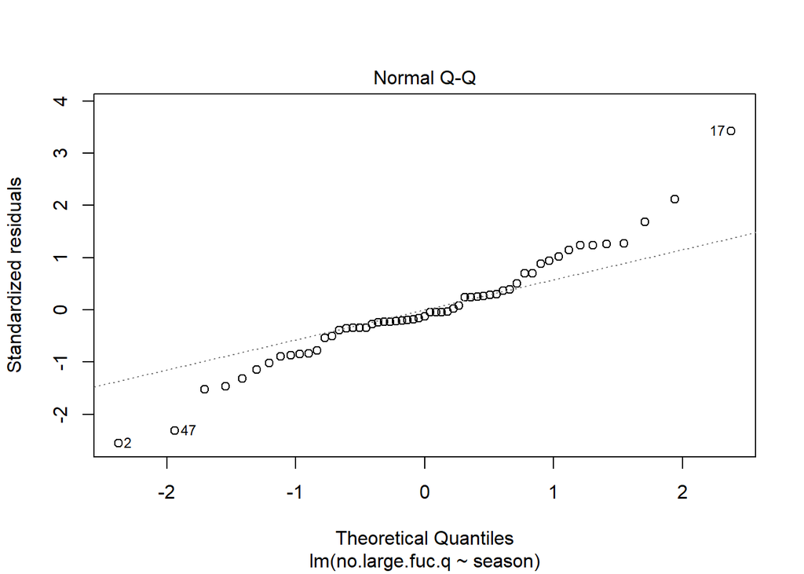

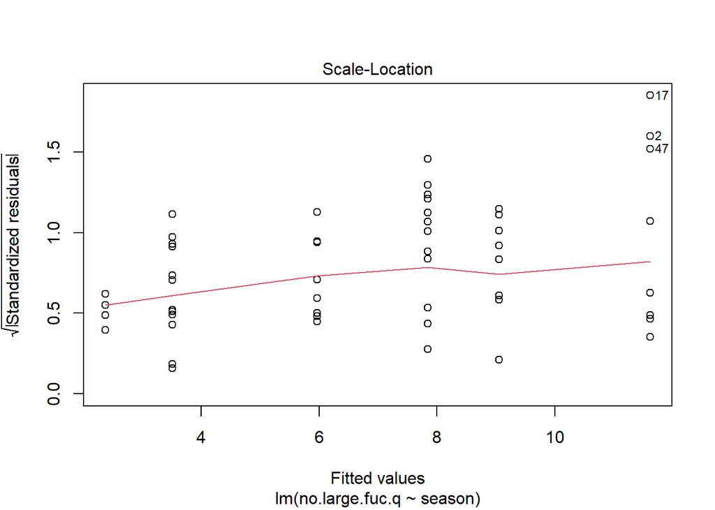

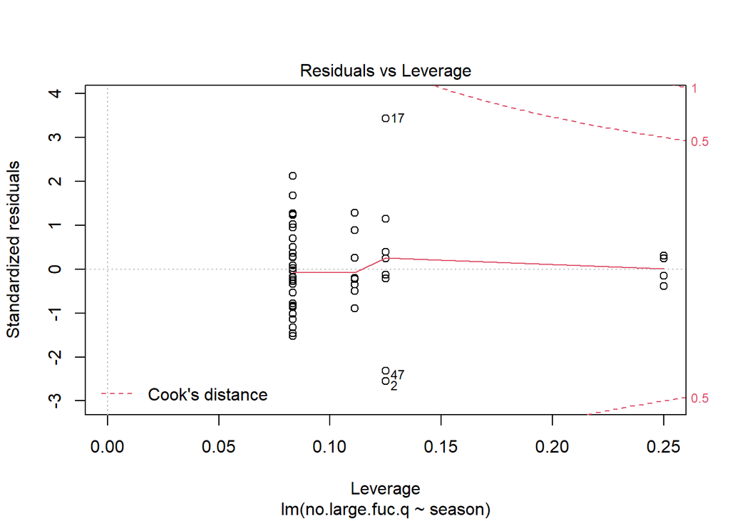

```r
plot (lm3.5)
```

####3.6 Is juvenile density affected by the season?####

```r
lm3.6 <- lm(no.small.fuc.q ~ season, data =all)
lm3.6
```

```
##
## Call:
## lm(formula = no.small.fuc.q ~ season, data = all)
##
## Coefficients:
##       (Intercept)    seasonfall.2019  seasonspring.2019  seasonsummer.2018
##             46.29             -24.79             -32.32              36.59
## seasonsummer.2019  seasonwinter.2018
##            -27.48             -32.35
```

```r
summary (lm3.6)
```

```
##
## Call:
## lm(formula = no.small.fuc.q ~ season, data = all)
##
## Residuals:
##     Min      1Q  Median      3Q     Max
## -68.575  -9.500  -1.667   4.358  70.211
##
## Coefficients:
##                   Estimate Std. Error t value Pr(>|t|)
## (Intercept)         46.289      8.521   5.433 1.56e-06 ***
## seasonfall.2019    -24.789     15.361  -1.614  0.11275
## seasonspring.2019  -32.322     11.272  -2.868  0.00600 **
## seasonsummer.2018   36.586     12.421   2.946  0.00485 **
## seasonsummer.2019  -27.481     11.272  -2.438  0.01829 *
## seasonwinter.2018  -32.347     11.272  -2.870  0.00596 **
## ---
## Signif. codes:  0 '***' 0.001 '**' 0.01 '*' 0.05 '.' 0.1 ' ' 1
##
## Residual standard error: 25.56 on 51 degrees of freedom
##   (4 observations deleted due to missingness)
## Multiple R-squared:  0.4954, Adjusted R-squared:  0.446
## F-statistic: 10.02 on 5 and 51 DF,  p-value: 1.021e-06
```

```r
anova (lm3.6)
```

```
## Analysis of Variance Table
##
## Response: no.small.fuc.q
##           Df Sum Sq Mean Sq F value    Pr(>F)
## season     5  32721  6544.2  10.015 1.021e-06 ***
## Residuals 51  33324   653.4
## ---
## Signif. codes:  0 '***' 0.001 '**' 0.01 '*' 0.05 '.' 0.1 ' ' 1
```

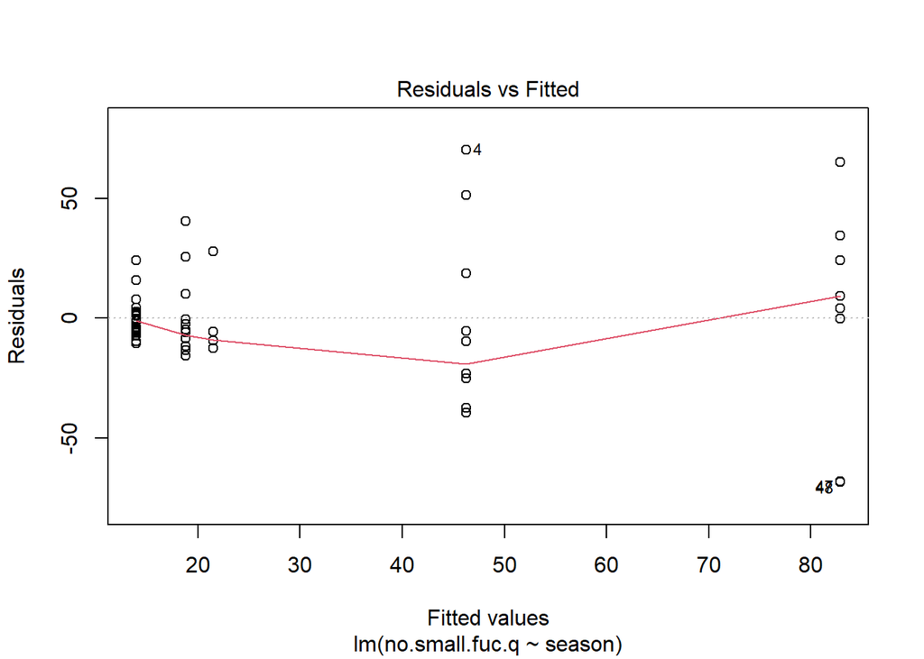

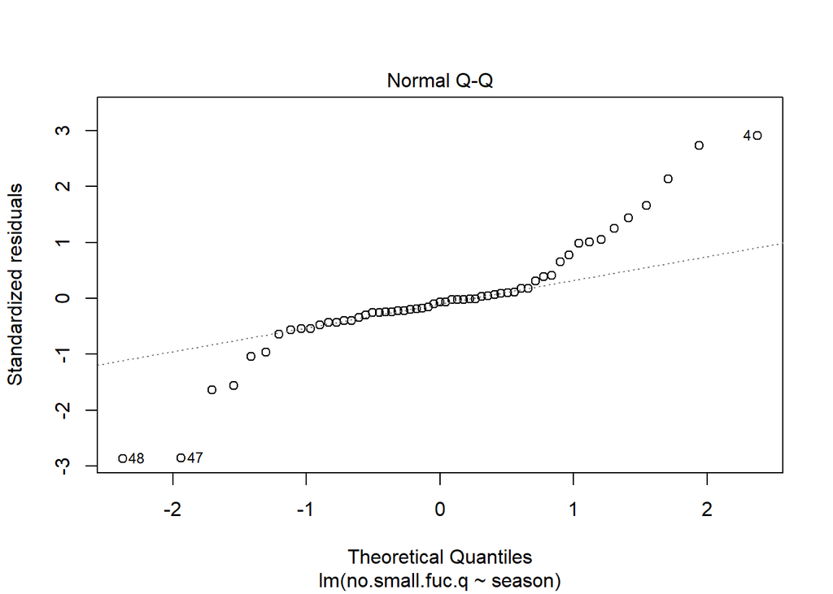

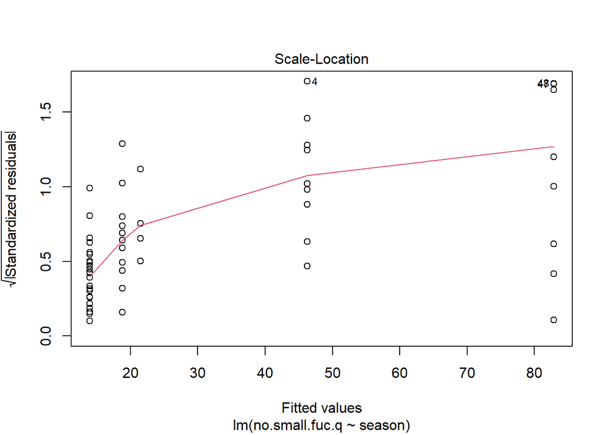

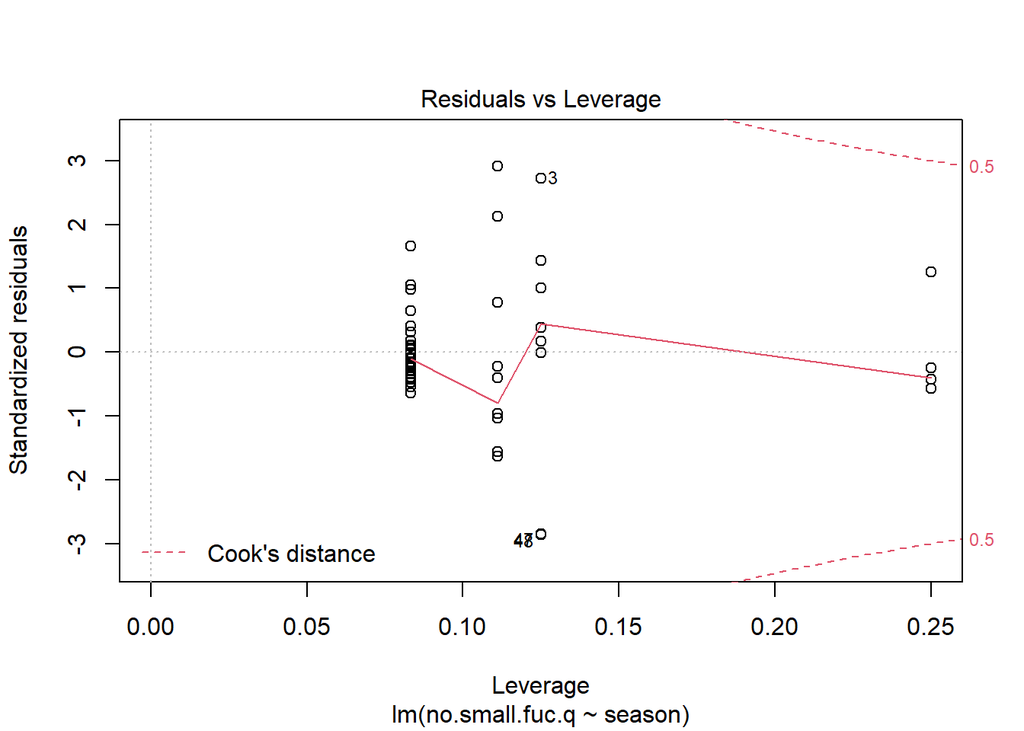

```r
plot (lm3.6)
```

####REPRODUCTIVE PHENOLOGY (without seasonality)###  
4. Is reproductive phenology affected by environmental conditions (salinity, pH, water temperature and air temperature)?  
TO DO: check which metric I should be using for each of these variables. For now just sticking with the mean between survey dates but I think mean daily minimun or maximum might be more interesting and insightful

####4.1 Is oogoina/receptical affected by environmental conditions (salinity, pH, water temperature and air temperature)?####

```r
lm4.1 <- lm(avg.oog ~ salinity + ph + water.temp, data =all)
lm4.1
```

```
##
## Call:
## lm(formula = avg.oog ~ salinity + ph + water.temp, data = all)
##
## Coefficients:
## (Intercept)     salinity           ph   water.temp
##     288.777        1.152      -29.813       -3.675
```

```r
summary (lm4.1)
```

```
##
## Call:
## lm(formula = avg.oog ~ salinity + ph + water.temp, data = all)
##
## Residuals:
##     Min      1Q  Median      3Q     Max
## -17.635  -9.566  -1.689   6.475  34.053
##
## Coefficients:
##             Estimate Std. Error t value Pr(>|t|)
## (Intercept) 288.7770   125.5277   2.301  0.02700 *
## salinity      1.1523     0.3257   3.537  0.00108 **
## ph          -29.8126    15.7331  -1.895  0.06573 .
## water.temp   -3.6748     0.8275  -4.441 7.48e-05 ***
## ---
## Signif. codes:  0 '***' 0.001 '**' 0.01 '*' 0.05 '.' 0.1 ' ' 1
##
## Residual standard error: 13.45 on 38 degrees of freedom
##   (19 observations deleted due to missingness)
## Multiple R-squared:  0.4057, Adjusted R-squared:  0.3588
## F-statistic: 8.647 on 3 and 38 DF,  p-value: 0.000168
```

```r
anova (lm4.1)
```

```
## Analysis of Variance Table
##
## Response: avg.oog
##            Df Sum Sq Mean Sq F value    Pr(>F)
## salinity    1  553.1   553.1  3.0584   0.08840 .
## ph          1  571.6   571.6  3.1611   0.08342 .
## water.temp  1 3566.6  3566.6 19.7230 7.477e-05 ***
## Residuals  38 6871.7   180.8
## ---
## Signif. codes:  0 '***' 0.001 '**' 0.01 '*' 0.05 '.' 0.1 ' ' 1
```

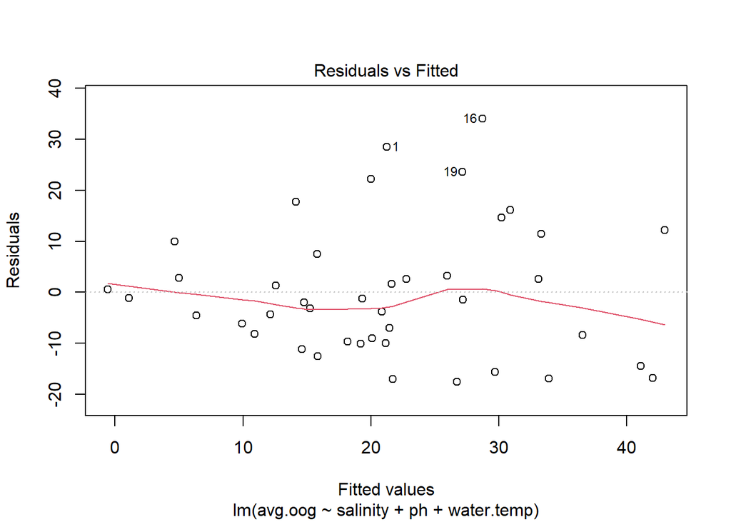

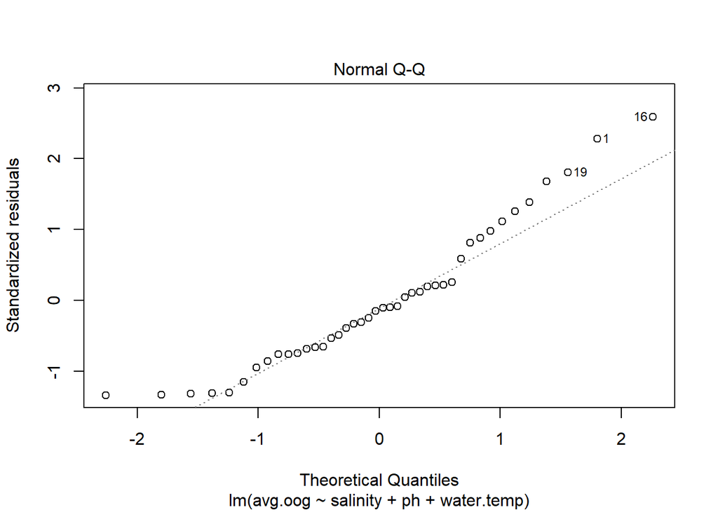

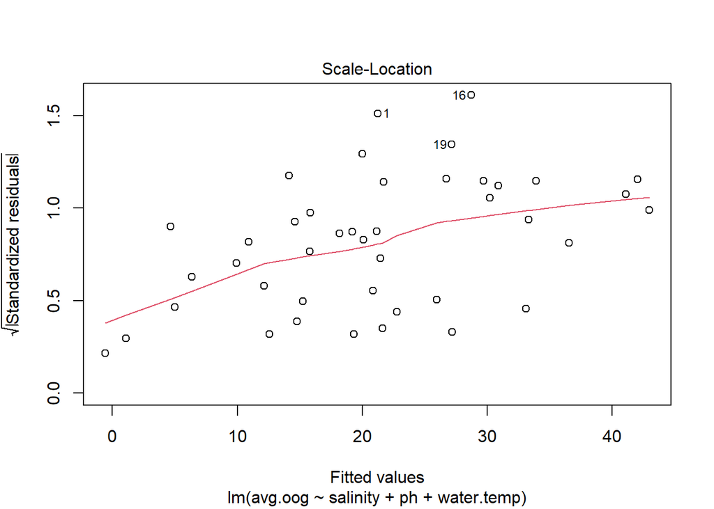

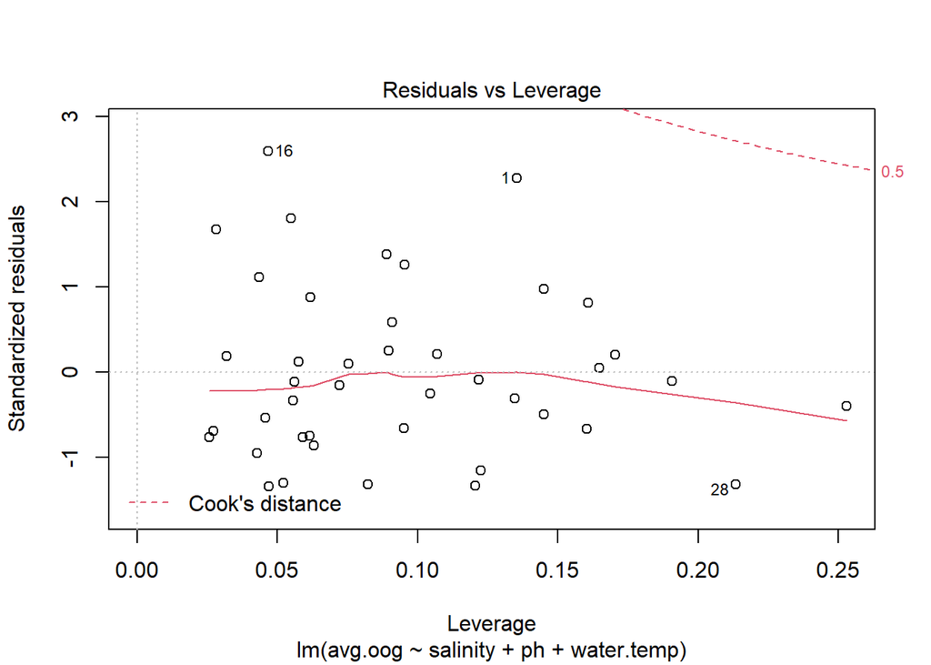

```r
plot (lm4.1)
```

####4.2 Is oogonia/thalli affected by environmental conditions (salinity, pH, water temperature and air temperature)?####

```r
lm4.2 <- lm(oog.thalli ~ salinity + ph + water.temp, data =all)
lm4.2
```

```
##
## Call:
## lm(formula = oog.thalli ~ salinity + ph + water.temp, data = all)
##
## Coefficients:
## (Intercept)     salinity           ph   water.temp
##     3068710         9392      -375880       -11561
```

```r
summary (lm4.2)
```

```
##
## Call:
## lm(formula = oog.thalli ~ salinity + ph + water.temp, data = all)
##
## Residuals:
##     Min      1Q  Median      3Q     Max
## -208605 -125253  -24487   61299  855759
##
## Coefficients:
##             Estimate Std. Error t value Pr(>|t|)
## (Intercept)  3068710    1784692   1.719   0.0937 .
## salinity        9392       4631   2.028   0.0496 *
## ph           -375881     223686  -1.680   0.1011
## water.temp    -11561      11764  -0.983   0.3320
## ---
## Signif. codes:  0 '***' 0.001 '**' 0.01 '*' 0.05 '.' 0.1 ' ' 1
##
## Residual standard error: 191200 on 38 degrees of freedom
##   (19 observations deleted due to missingness)
## Multiple R-squared:  0.1627, Adjusted R-squared:  0.09662
## F-statistic: 2.462 on 3 and 38 DF,  p-value: 0.07734
```

```r
anova (lm4.2)
```

```
## Analysis of Variance Table
##
## Response: oog.thalli
##            Df     Sum Sq    Mean Sq F value  Pr(>F)
## salinity    1 1.3454e+11 1.3454e+11  3.6806 0.06259 .
## ph          1 1.0012e+11 1.0012e+11  2.7389 0.10617
## water.temp  1 3.5297e+10 3.5297e+10  0.9656 0.33199
## Residuals  38 1.3890e+12 3.6553e+10
## ---
## Signif. codes:  0 '***' 0.001 '**' 0.01 '*' 0.05 '.' 0.1 ' ' 1
```

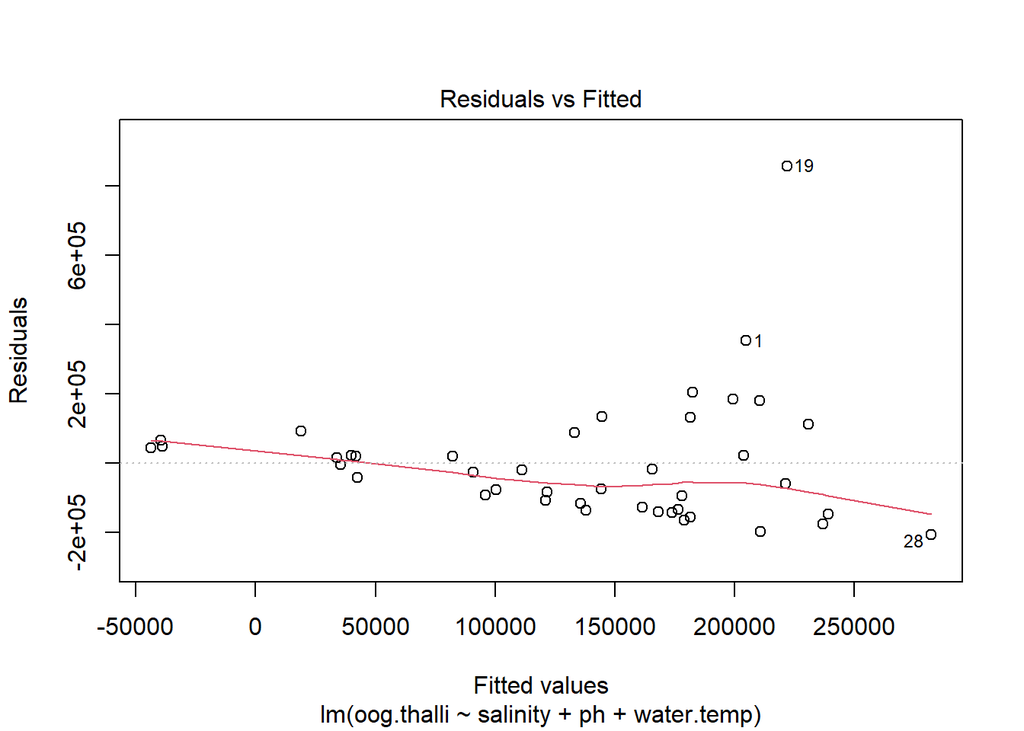

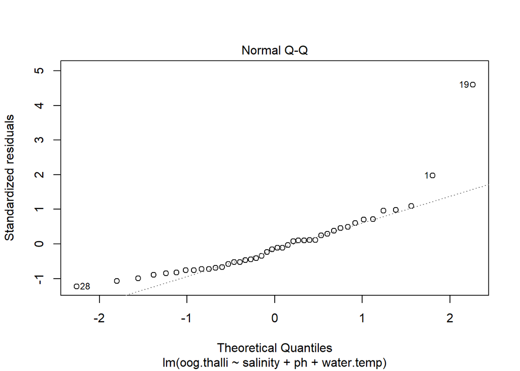

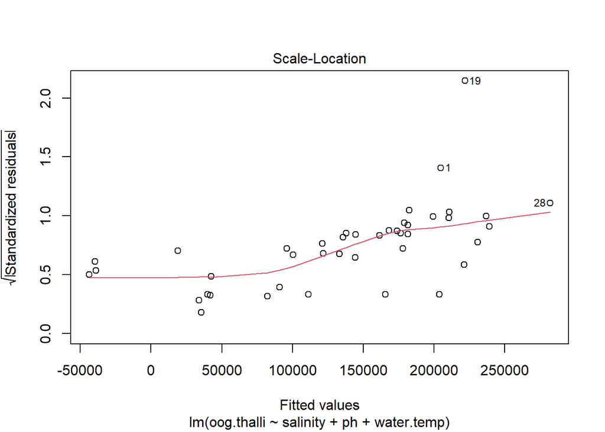

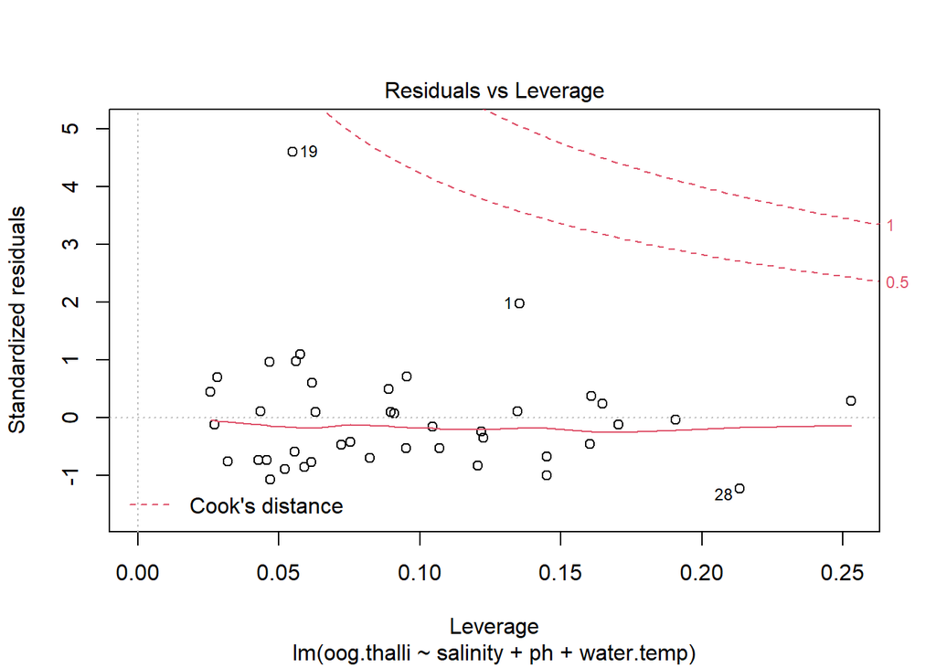

```r
plot (lm4.2)
```

####4.3 Is conceptacle/thalli affected by environmental conditions (salinity, pH, water temperature and air temperature)?####

```r
lm4.3 <- lm(con.thalli ~ salinity + ph + water.temp, data =all)
lm4.3
```

```
##
## Call:
## lm(formula = con.thalli ~ salinity + ph + water.temp, data = all)
##
## Coefficients:
## (Intercept)     salinity           ph   water.temp
##     58775.2        161.4      -6342.5       -129.4
```

```r
summary (lm4.3)
```

```
##
## Call:
## lm(formula = con.thalli ~ salinity + ph + water.temp, data = all)
##
## Residuals:
##    Min     1Q Median     3Q    Max
## -10380  -5529  -2928   2812  31992
##
## Coefficients:
##             Estimate Std. Error t value Pr(>|t|)
## (Intercept)  58775.2    85416.1   0.688    0.496
## salinity       161.4      221.7   0.728    0.471
## ph           -6342.5    10705.7  -0.592    0.557
## water.temp    -129.4      563.1  -0.230    0.819
##
## Residual standard error: 9150 on 38 degrees of freedom
##   (19 observations deleted due to missingness)
## Multiple R-squared:  0.02485,    Adjusted R-squared:  -0.05213
## F-statistic: 0.3229 on 3 and 38 DF,  p-value: 0.8088
```

```r
anova (lm4.3)
```

```
## Analysis of Variance Table
##
## Response: con.thalli
##            Df     Sum Sq  Mean Sq F value Pr(>F)
## salinity    1   47864762 47864762  0.5717 0.4543
## ph          1   28807975 28807975  0.3441 0.5610
## water.temp  1    4423765  4423765  0.0528 0.8194
## Residuals  38 3181730439 83729748
```

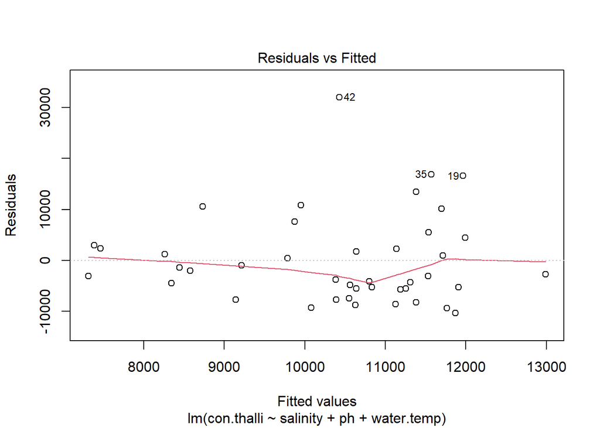

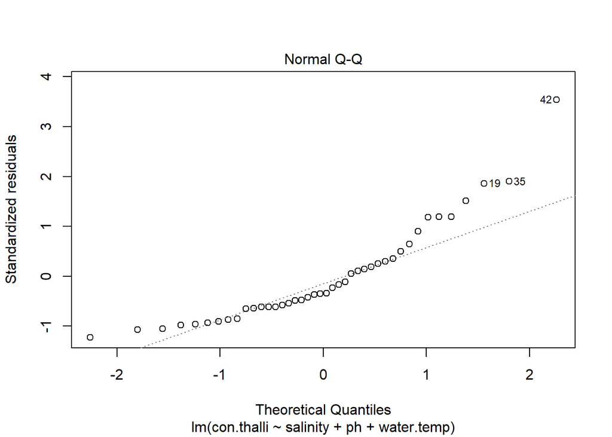

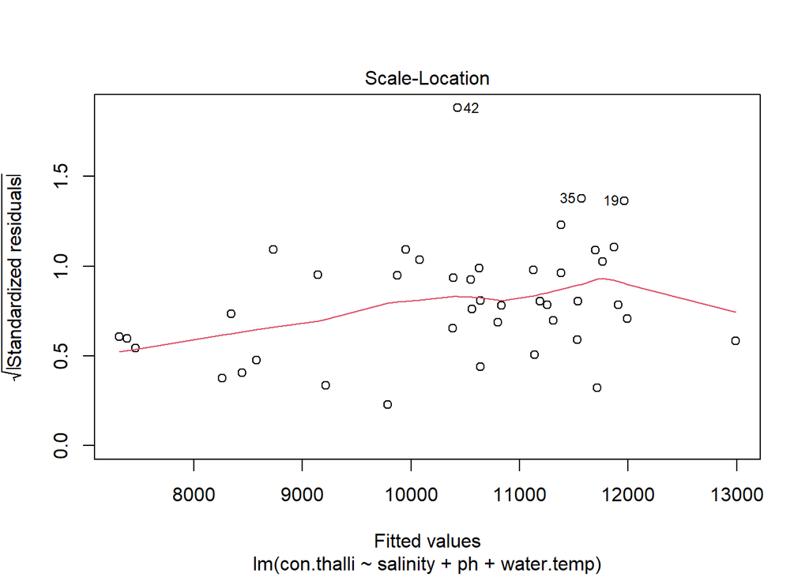

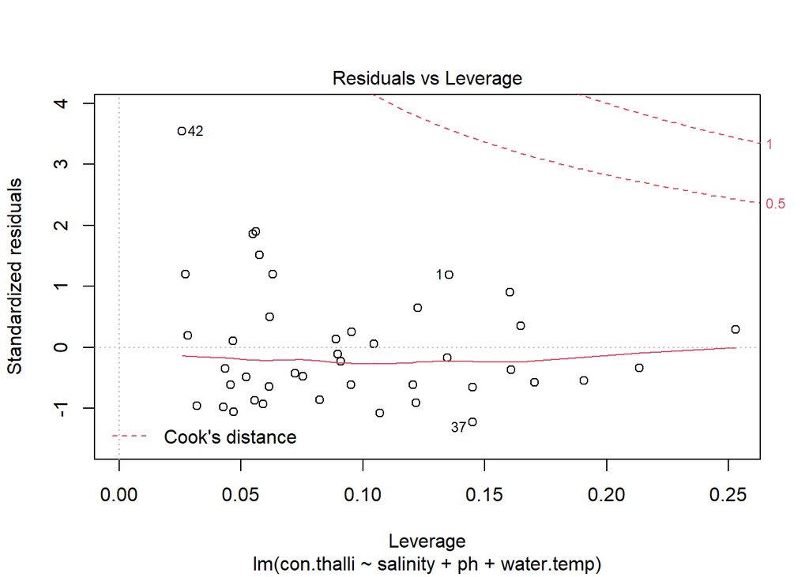

```r
plot (lm4.3)
```

####4.4 Is percent reproductive tissue affected by environmental conditions (salinity, pH, water temperature and air temperature)?####

```r
lm4.4 <- lm(perc.rdw ~ salinity + ph + water.temp, data =all)
lm4.4
```

```
##
## Call:
## lm(formula = perc.rdw ~ salinity + ph + water.temp, data = all)
##
## Coefficients:
## (Intercept)     salinity           ph   water.temp
##    329.7386       0.2022     -40.9228       0.3886
```

```r
summary (lm4.4)
```

```
##
## Call:
## lm(formula = perc.rdw ~ salinity + ph + water.temp, data = all)
##
## Residuals:
##     Min      1Q  Median      3Q     Max
## -17.097 -11.126  -1.268   9.220  29.659
##
## Coefficients:
##             Estimate Std. Error t value Pr(>|t|)
## (Intercept) 329.7386   122.9021   2.683   0.0107 *
## salinity      0.2022     0.3189   0.634   0.5298
## ph          -40.9228    15.4040  -2.657   0.0115 *
## water.temp    0.3886     0.8102   0.480   0.6343
## ---
## Signif. codes:  0 '***' 0.001 '**' 0.01 '*' 0.05 '.' 0.1 ' ' 1
##
## Residual standard error: 13.17 on 38 degrees of freedom
##   (19 observations deleted due to missingness)
## Multiple R-squared:  0.1886, Adjusted R-squared:  0.1246
## F-statistic: 2.945 on 3 and 38 DF,  p-value: 0.04509
```

```r
anova (lm4.4)
```

```
## Analysis of Variance Table
##
## Response: perc.rdw
##            Df Sum Sq Mean Sq F value  Pr(>F)
## salinity    1  255.6  255.57  1.4743 0.23216
## ph          1 1236.0 1236.03  7.1303 0.01109 *
## water.temp  1   39.9   39.87  0.2300 0.63426
## Residuals  38 6587.2  173.35
## ---
## Signif. codes:  0 '***' 0.001 '**' 0.01 '*' 0.05 '.' 0.1 ' ' 1
```

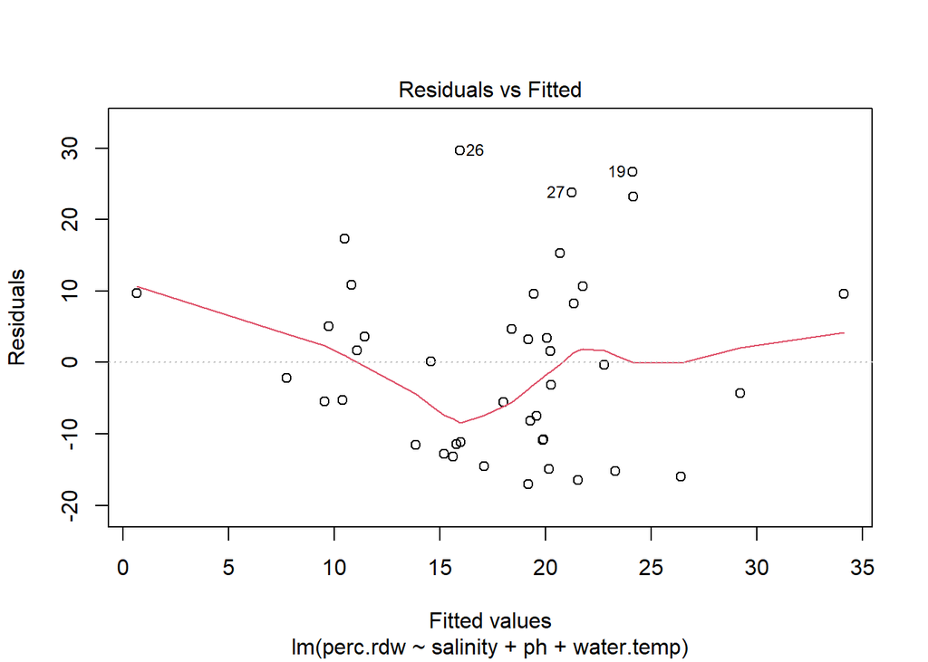

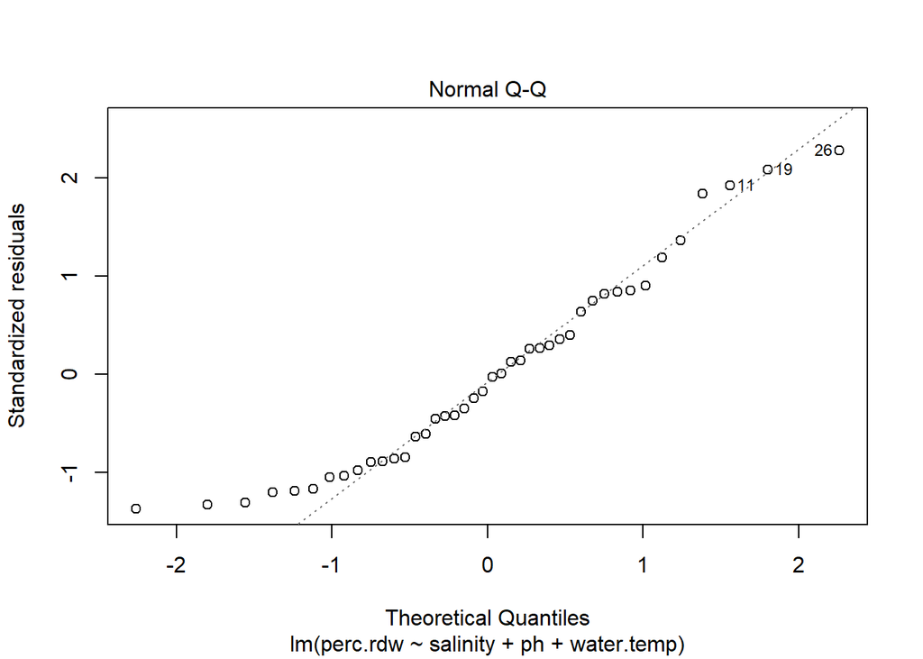

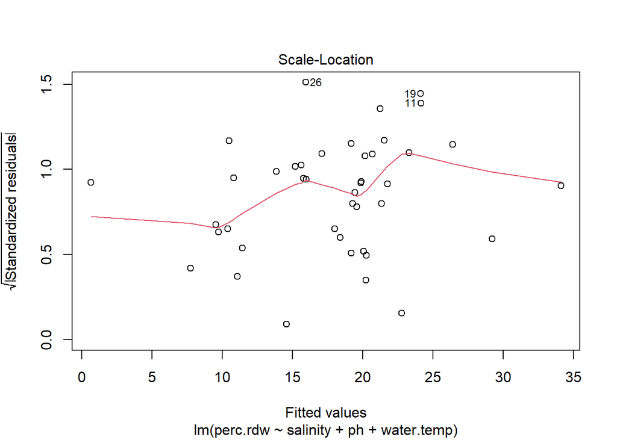

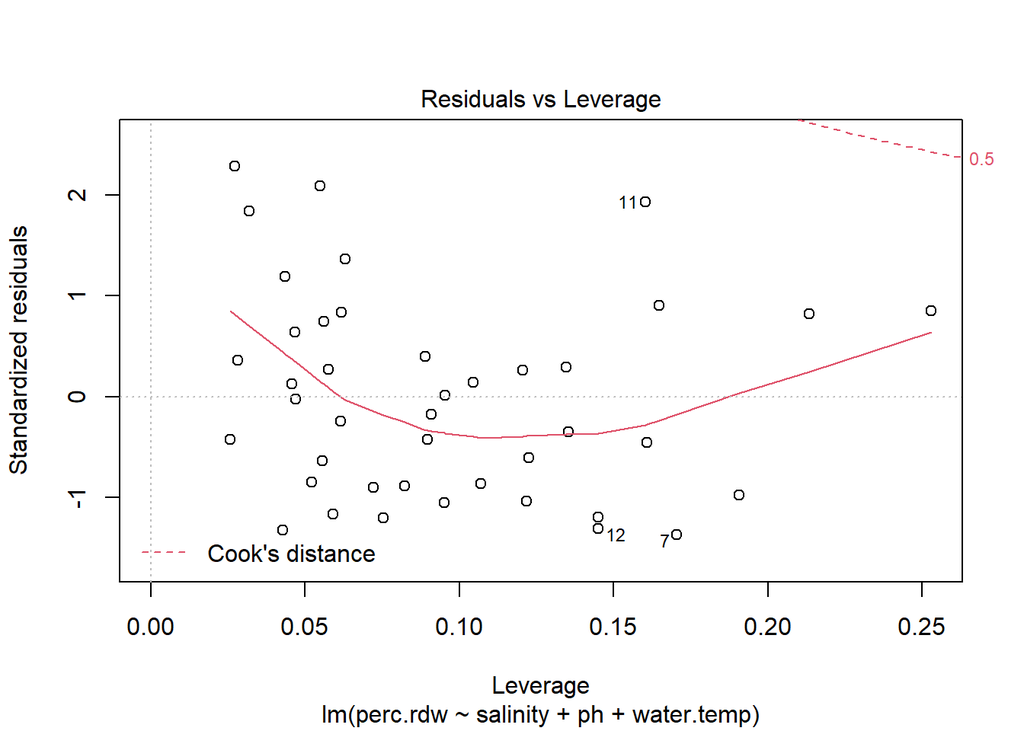

```r
plot (lm4.4)
```

####4.5 Is juvenile density affected by environmental conditions (salinity, pH, water temperature and air temperature)?####

```r
lm4.5 <- lm(no.small.fuc.q ~ salinity + ph + water.temp, data =all)
lm4.5
```

```
##
## Call:
## lm(formula = no.small.fuc.q ~ salinity + ph + water.temp, data = all)
##
## Coefficients:
## (Intercept)     salinity           ph   water.temp
##    -196.608        1.501       14.907        4.941
```

```r
summary (lm4.5)
```

```
##
## Call:
## lm(formula = no.small.fuc.q ~ salinity + ph + water.temp, data = all)
##
## Residuals:
##     Min      1Q  Median      3Q     Max
## -48.774 -20.807  -6.178  19.982  83.552
##
## Coefficients:
##              Estimate Std. Error t value Pr(>|t|)
## (Intercept) -196.6076   314.3187  -0.626   0.5354
## salinity       1.5011     0.7607   1.973   0.0558 .
## ph            14.9069    39.4949   0.377   0.7079
## water.temp     4.9405     1.8316   2.697   0.0104 *
## ---
## Signif. codes:  0 '***' 0.001 '**' 0.01 '*' 0.05 '.' 0.1 ' ' 1
##
## Residual standard error: 31.22 on 38 degrees of freedom
##   (19 observations deleted due to missingness)
## Multiple R-squared:  0.3624, Adjusted R-squared:  0.3121
## F-statistic:   7.2 on 3 and 38 DF,  p-value: 0.0006082
```

```r
anova (lm4.5)
```

```
## Analysis of Variance Table
##
## Response: no.small.fuc.q
##            Df Sum Sq Mean Sq F value    Pr(>F)
## salinity    1  13787 13787.0 14.1477 0.0005693 ***
## ph          1    172   172.2  0.1767 0.6766207
## water.temp  1   7091  7090.6  7.2761 0.0103617 *
## Residuals  38  37031   974.5
## ---
## Signif. codes:  0 '***' 0.001 '**' 0.01 '*' 0.05 '.' 0.1 ' ' 1
```

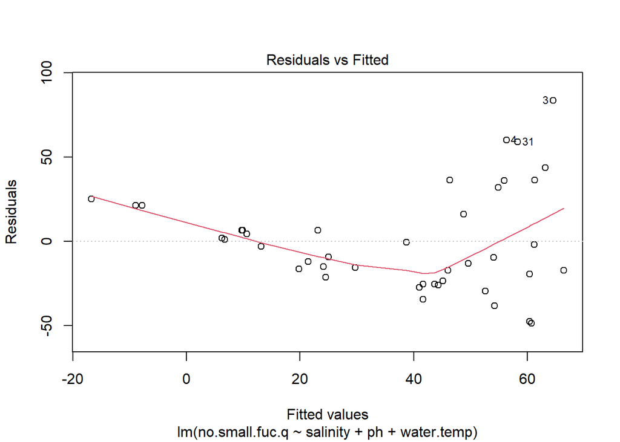

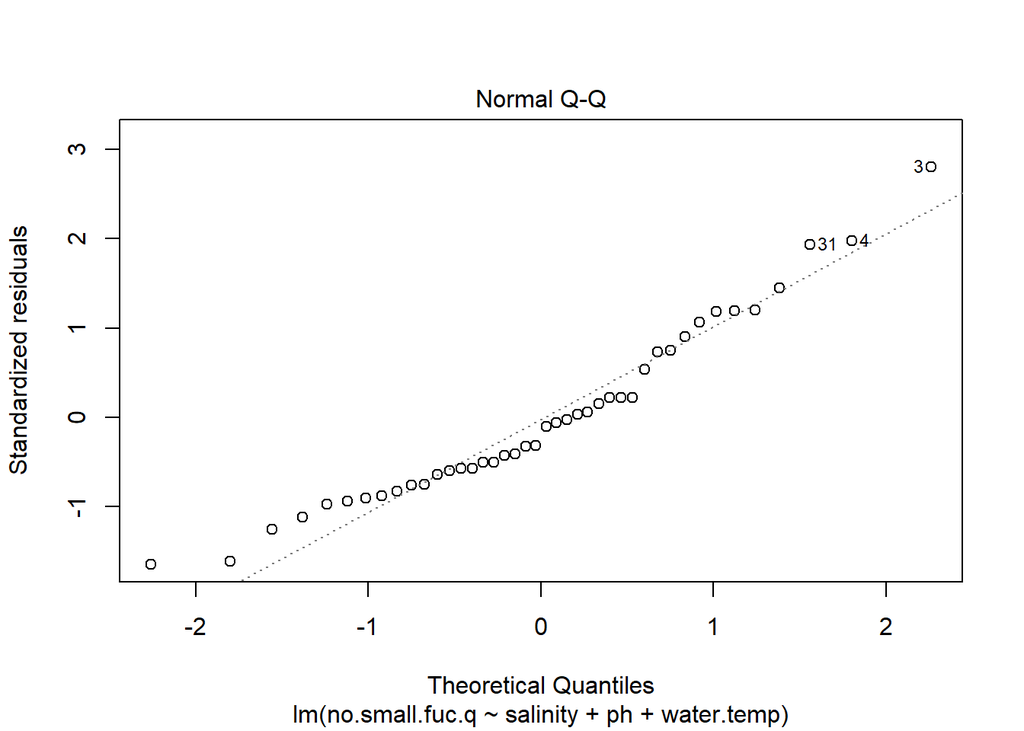

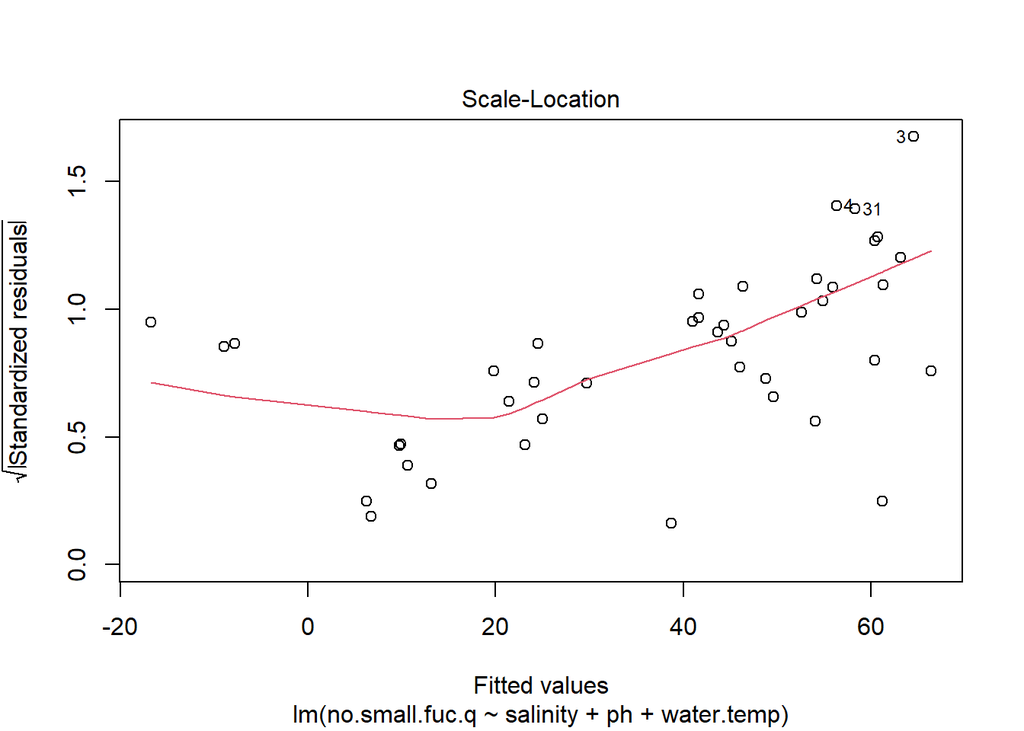

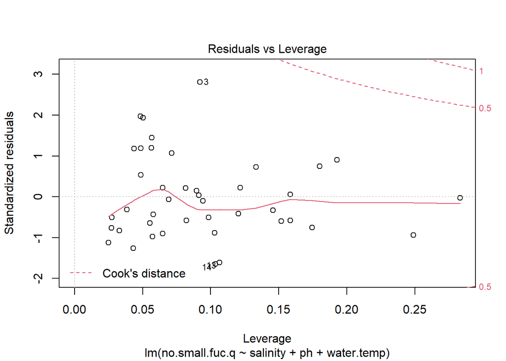

```r
plot (lm4.5)
```

####4.6 Is adult density affected by environmental conditions (salinity, pH, water temperature and air temperature)?####

```r
lm4.6 <- lm(no.large.fuc.q ~ salinity + ph + water.temp, data =all)
lm4.6
```

```
##
## Call:
## lm(formula = no.large.fuc.q ~ salinity + ph + water.temp, data = all)
##
## Coefficients:
## (Intercept)     salinity           ph   water.temp
##  -11.428619     0.009459     3.089848    -0.368876
```

```r
summary (lm4.6)
```

```
##
## Call:
## lm(formula = no.large.fuc.q ~ salinity + ph + water.temp, data = all)
##
## Residuals:
##    Min     1Q Median     3Q    Max
## -6.057 -3.407 -1.521  3.009 16.395
##
## Coefficients:
##               Estimate Std. Error t value Pr(>|t|)
## (Intercept) -11.428619  49.474480  -0.231    0.819
## salinity      0.009459   0.119731   0.079    0.937
## ph            3.089848   6.216584   0.497    0.622
## water.temp   -0.368876   0.288292  -1.280    0.208
##
## Residual standard error: 4.914 on 38 degrees of freedom
##   (19 observations deleted due to missingness)
## Multiple R-squared:  0.05791,    Adjusted R-squared:  -0.01646
## F-statistic: 0.7786 on 3 and 38 DF,  p-value: 0.5132
```

```r
anova (lm4.6)
```

```
## Analysis of Variance Table
##
## Response: no.large.fuc.q
##            Df Sum Sq Mean Sq F value Pr(>F)
## salinity    1  11.38  11.382  0.4714 0.4965
## ph          1   5.49   5.488  0.2273 0.6362
## water.temp  1  39.53  39.528  1.6372 0.2085
## Residuals  38 917.47  24.144
```

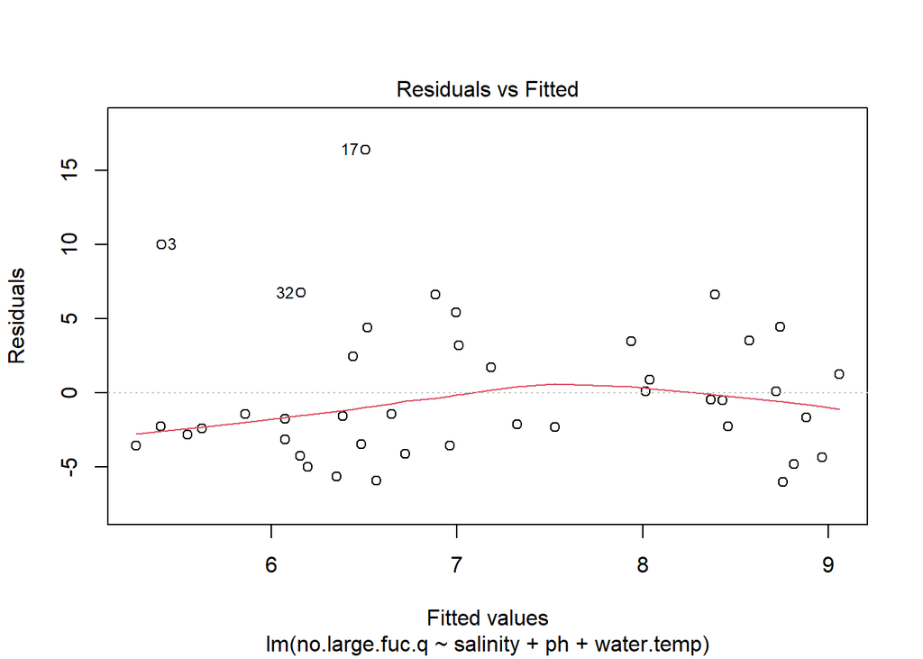

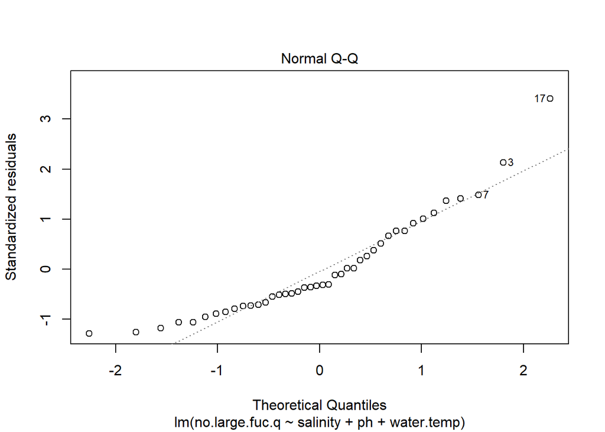

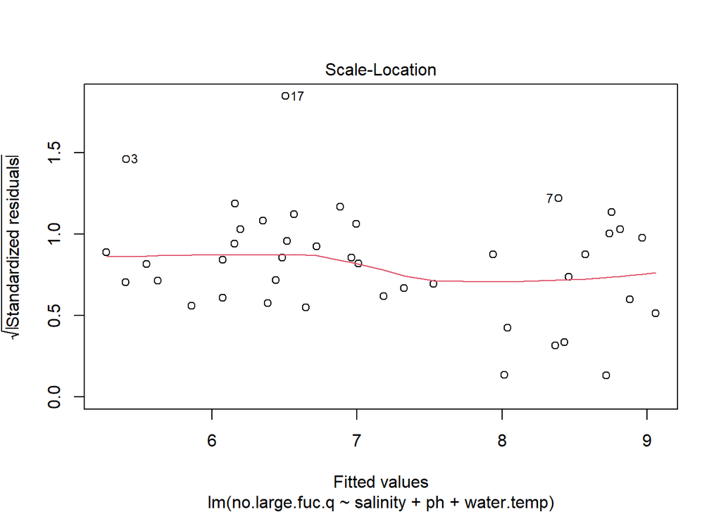

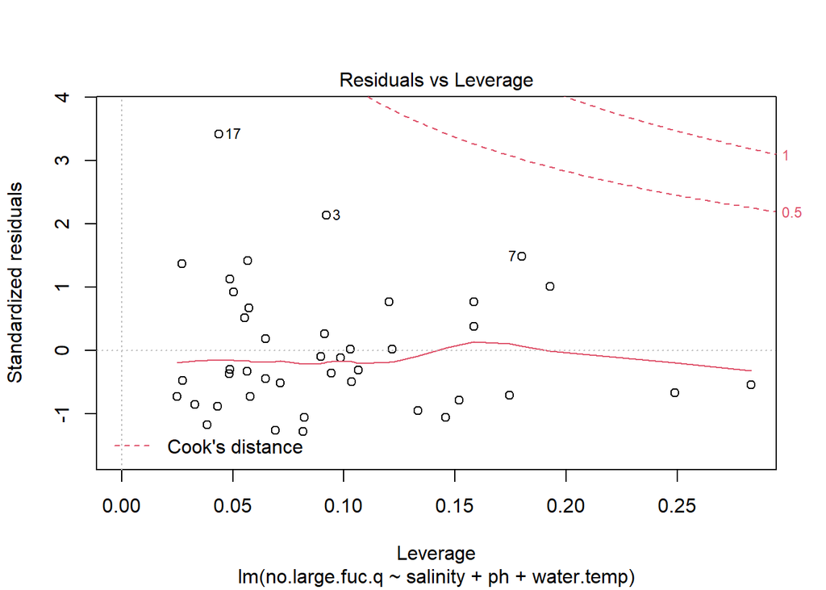

```r
plot (lm4.6)
```